# Importing Libraries

```python
# This Python 3 environment comes with many helpful analytics libraries installed
# It is defined by the kaggle/python Docker image: https://github.com/kaggle/docker-python
# For example, here's several helpful packages to load

import numpy as np # linear algebra
import pandas as pd # data processing, CSV file I/O (e.g. pd.read_csv)

# Input data files are available in the read-only "../input/" directory
# For example, running this (by clicking run or pressing Shift+Enter) will list all files under the input directory

import os
#for dirname, _, filenames in os.walk('/kaggle/input'):
#    for filename in filenames:
#        print(os.path.join(dirname, filename))

# You can write up to 20GB to the current directory (/kaggle/working/) that gets preserved as output when you create a version using "Save & Run All"
# You can also write temporary files to /kaggle/temp/, but they won't be saved outside of the current session
```

```python
import matplotlib.pyplot as plt # for data visualization
import time # for timing certain cells
import string # for identifying punctuation

from nltk.tokenize import word_tokenize # for word tokenization
from tensorflow.keras.preprocessing.text import Tokenizer # creates vocabulary & maps words to integers
from tensorflow.keras.preprocessing.sequence import pad_sequences # adjusts tokenized texts to all be of the same length

from tensorflow import keras
from tensorflow.keras.models import Sequential
from tensorflow.keras.layers import Input, Embedding, LSTM, GRU, Dropout, Dense, SpatialDropout1D
from tensorflow.keras.initializers import Constant
from tensorflow.keras.optimizers import Adam
from tensorflow.keras.callbacks import EarlyStopping, ReduceLROnPlateau

from sklearn.metrics import roc_curve, auc, roc_auc_score, confusion_matrix
from sklearn.metrics import ConfusionMatrixDisplay
```

# Project Background

This project involves building a model that analyzes users' social media posts on Twitter, and predicts which ones are referring to actual natural disasters happening in the area. This is a powerful tool that disaster relief organizations and news agencies would use to quickly understand what disasters are occurring in what areas, and gather information about them from people in the area observing these in real time. Many posts however may contain words that are are commonly used to describe disasters, such as "ablaze" or "fire", but not actually be referring to an emergency incident. The model we build will be able to reliably separate such posts from those referring to actual disasters with high accuracy.

10,000 tweets are collected for the purpose of model training and evaluation. In this Kaggle competition, the evaluation metric of choice is the F1 score which is computed as:

$$ \text{F1 Score} = 2 \times \frac{precision \times recall}{precision + recall} $$

# Loading Data

```python
train = pd.read_csv('/kaggle/input/nlp-getting-started/train.csv')
test = pd.read_csv('/kaggle/input/nlp-getting-started/test.csv')
sample = pd.read_csv('/kaggle/input/nlp-getting-started/sample_submission.csv')
```

# Exploratory Data Analysis

```python
train.info()
train.head()
```

```
<class 'pandas.core.frame.DataFrame'>
RangeIndex: 7613 entries, 0 to 7612
Data columns (total 5 columns):
 #   Column    Non-Null Count  Dtype
---  ------    --------------  -----
 0   id        7613 non-null   int64
 1   keyword   7552 non-null   object
 2   location  5080 non-null   object
 3   text      7613 non-null   object
 4   target    7613 non-null   int64
dtypes: int64(2), object(3)
memory usage: 297.5+ KB
```

|  | id | keyword | location | text | target |
| --- | --- | --- | --- | --- | --- |
| 0 | 1 | NaN | NaN | Our Deeds are the Reason of this #earthquake M... | 1 |
| 1 | 4 | NaN | NaN | Forest fire near La Ronge Sask. Canada | 1 |
| 2 | 5 | NaN | NaN | All residents asked to 'shelter in place' are ... | 1 |
| 3 | 6 | NaN | NaN | 13,000 people receive #wildfires evacuation or... | 1 |
| 4 | 7 | NaN | NaN | Just got sent this photo from Ruby #Alaska as ... | 1 |

```python
test.info()
test.head()
```

```
<class 'pandas.core.frame.DataFrame'>
RangeIndex: 3263 entries, 0 to 3262
Data columns (total 4 columns):
 #   Column    Non-Null Count  Dtype
---  ------    --------------  -----
 0   id        3263 non-null   int64
 1   keyword   3237 non-null   object
 2   location  2158 non-null   object
 3   text      3263 non-null   object
dtypes: int64(1), object(3)
memory usage: 102.1+ KB
```

|  | id | keyword | location | text |
| --- | --- | --- | --- | --- |
| 0 | 0 | NaN | NaN | Just happened a terrible car crash |
| 1 | 2 | NaN | NaN | Heard about #earthquake is different cities, s... |
| 2 | 3 | NaN | NaN | there is a forest fire at spot pond, geese are... |
| 3 | 9 | NaN | NaN | Apocalypse lighting. #Spokane #wildfires |
| 4 | 11 | NaN | NaN | Typhoon Soudelor kills 28 in China and Taiwan |

- The training data consists of 7,613 records.
- The columns 'keyword' and 'location' have null values which need to be investigated.
- The column 'target' holds the training label 1 for tweets referring to actual natural disasters, and 0 otherwise.
- The test data consists of 3,263 records.
- It has the same columns as the training dataset, minus the 'target' column since there's no labels. The columns 'keyword' and 'location' also contain nulls here. Any imputations we do in the training data will need to also be done on the test data.

### Investigating 'Keyword' and 'Location' columns

```python
pd.set_option('display.max_colwidth', None) # so we can see the full tweet

train[~train['keyword'].isna()].sample(10, random_state = 78).iloc[:,:4]
```

|  | id | keyword | location | text |
| --- | --- | --- | --- | --- |
| 4494 | 6391 | hurricane | Haiku, Maui, Hawaii | HURRICANE GUILLERMO LIVE NOAA TRACKING / LOOPING WED.AUG.5TH ~ http://t.co/ut7R2ixRjQ ~ http://t.co/v3z96YDMvD http://t.co/kxSLfTZ2I5 |
| 1806 | 2594 | crash | NaN | I see dat we liable to fuck up and crash ???? |
| 4413 | 6273 | hijacking | between ideas & 3-5pm AEST | to whomever is hijacking my wifi hotspot. I have a very specific skill set. I will create a character and perform a one-man show about you |
| 2725 | 3914 | devastated | London | ÛÏRichmond Coaches were devastated to hear of the death of their second driver Mr Chance who was sittingÛ_: Jam... http://t.co/dIalTa6t69 |
| 1192 | 1718 | bridge%20collapse | NY, CT & Greece | US wont upgrade its infrastructure? http://t.co/NGEHhG9YGa' it a bad situation and its going to get ugly very quickly #USA #sustainability |
| 4212 | 5983 | hazard | NaN | 8/6/2015@1:08 PM: HAZARD IN HIGH TRAFFIC AREA at 1500 WRIGHTSBORO RD http://t.co/DdUxtHvVnr |
| 4487 | 6383 | hostages | The Universe | Cont'd- #Sinjar: referring to a 40-pg document the group put together on the movt of #Yazidi hostages in the days following #IS massacre [2] |
| 2142 | 3074 | deaths | NaN | @Eazzy_P we will never know what would have happened but the govt seemed to think that their beliefs warranted the deaths of innocent japs |
| 5347 | 7633 | pandemonium | Los Angeles | Pandemonium In Aba As Woman Delivers Baby Without Face (Photos) - http://t.co/Ykdsp0nRDQ |
| 1158 | 1669 | bombing | London | Japan marks 70th anniversary of Hiroshima atomic bombing: Bells tolled in Hiroshima on Thursday as Japan marked 70Û_ http://t.co/NBZiKcJpHp |

```python
pd.reset_option('display.max_colwidth')
```

- We see here in these samples that 'keyword' is a word or phrase from the text, that are words commonly used to describe a natural disaster or emergency incident.
- It seems like a search for disaster-related keywords was done on Twitter, and all tweets containing those words were used to build this dataset, and the relevant keyword is included in the 'keyword' column.
- Since the keywords are already included in the text, it wouldn't offer any new information for our model and so can be excluded from consideration.
- Location sometimes contains geographic information, but also often does not. It looks to be taken from a freeform text field, and will be of limited use for the model. For purposes of this project, it can be excluded.

### Checking balance of training data

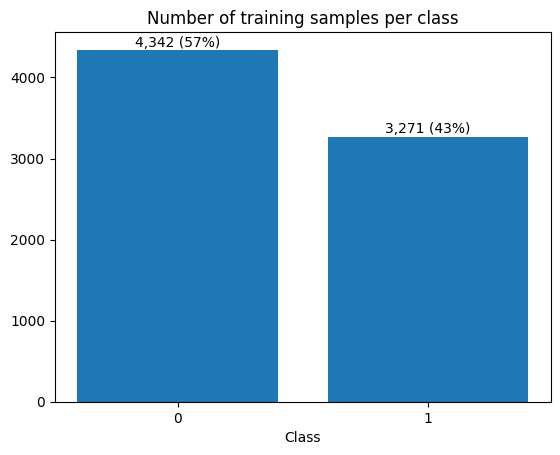

```python
fig, ax = plt.subplots(1, 1)

ax.bar(x = ['0', '1'], height = train['target'].value_counts())
ax.set_xlabel('Class')
ax.set_title('Number of training samples per class')

labels = train['target'].value_counts()
labels_pct = (labels / labels.sum()) * 100

for bar, label, pct in zip(ax.patches, labels, labels_pct):
    height = bar.get_height()
    ax.text(
        bar.get_x() + bar.get_width() / 2, height + 5, f'{label:,d} ({pct:.0f}%)', ha = 'center', va = 'bottom'
    )
```

- Class 0 (negative label) comprises 57% and Class 1 (positive label) comprises 43%.
- The training data is well balanced, and we have good representation of both negative and positively labeled samples.

### Checking length of texts

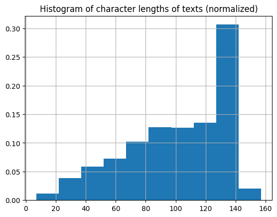

|  | count | percent |
| --- | --- | --- |
| (6.848999999999999, 22.0] | 99 | 0.013004 |
| (22.0, 37.0] | 300 | 0.039406 |
| (37.0, 52.0] | 461 | 0.060554 |
| (52.0, 67.0] | 565 | 0.074215 |
| (67.0, 82.0] | 784 | 0.102982 |
| (82.0, 97.0] | 988 | 0.129778 |
| (97.0, 112.0] | 960 | 0.126100 |
| (112.0, 127.0] | 1024 | 0.134507 |
| (127.0, 142.0] | 2332 | 0.306318 |
| (142.0, 157.0] | 100 | 0.013135 |

```python
char_lengths = train['text'].str.len()

char_lengths.hist(weights = np.ones(len(char_lengths)) / len(char_lengths))
plt.title('Histogram of character lengths of texts (normalized)')
plt.show()

cnt = char_lengths.value_counts(bins = 10).sort_index()
pct = char_lengths.value_counts(bins = 10, normalize = True).sort_index()

pd.DataFrame({'count': cnt, 'percent': pct})
```

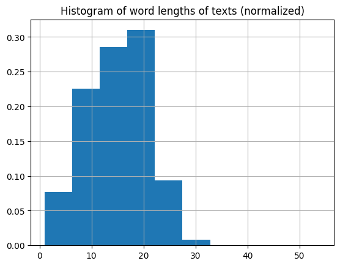

|  | count | percent |
| --- | --- | --- |
| (0.946, 6.3] | 582 | 0.076448 |
| (6.3, 11.6] | 1718 | 0.225667 |
| (11.6, 16.9] | 2174 | 0.285564 |
| (16.9, 22.2] | 2359 | 0.309865 |
| (22.2, 27.5] | 714 | 0.093787 |
| (27.5, 32.8] | 65 | 0.008538 |
| (32.8, 38.1] | 0 | 0.000000 |
| (38.1, 43.4] | 0 | 0.000000 |
| (43.4, 48.7] | 0 | 0.000000 |
| (48.7, 54.0] | 1 | 0.000131 |

```python
word_lengths = train['text'].str.split(pat = ' ').apply(len)

word_lengths.hist(weights = np.ones(len(word_lengths)) / len(word_lengths))
plt.title('Histogram of word lengths of texts (normalized)')
plt.show()

cnt = word_lengths.value_counts(bins = 10).sort_index()
pct = word_lengths.value_counts(bins = 10, normalize = True).sort_index()

pd.DataFrame({'count': cnt, 'percent': pct})
```

- The text in the dataset ranges from 7 to 157 characters long, and 1 to 54 words long. These don't seem particularly large, and we should have no problems vectorizing the text into useful data for training a model.
- The distribution of character lengths is left-skewed, and the most common range of character lengths is 127 to 142, which comrpises about 31% of the samples in the training set.
- The distribution of word lengths is also left-skewed though to a lesser extent than the distribution of character lengths. The most common number of words in the text samples is 17 to 22, and 31% of the training samples fall into this range.

# Text Cleaning

In this step we clean the text data to remove punctuations (.,! etc.) since they don't offer much meaning or pattern to text meanings that a model can learn from.

Stop words such as 'the', 'and', 'a', etc. will be preserved in the text and not removed for now, since it's possible for them to provide context in certain texts.

We'll use a simple pandas string replace function to strip the punctuation. There's also a handy library 'string' which provides a list of all commonly used punctuations.

```python
train['text'] = train['text'].str.replace('[{}]'.format(string.punctuation), '', regex = True)
```

# Word Tokenization

The tweet text in the data is currently in string format, and we need a numerical representation of the texts and the words contained to be able to use in a model for training.

### Split texts into individual words and add to a list

```python
texts = []

for text in train['text'].str.lower():
    texts.append(word_tokenize(text))

texts[0:3] # sample of what's contained in texts
```

```
[['our',
  'deeds',
  'are',
  'the',
  'reason',
  'of',
  'this',
  'earthquake',
  'may',
  'allah',
  'forgive',
  'us',
  'all'],
 ['forest', 'fire', 'near', 'la', 'ronge', 'sask', 'canada'],
 ['all',
  'residents',
  'asked',
  'to',
  'shelter',
  'in',
  'place',
  'are',
  'being',
  'notified',
  'by',
  'officers',
  'no',
  'other',
  'evacuation',
  'or',
  'shelter',
  'in',
  'place',
  'orders',
  'are',
  'expected']]
```

### Encode numerically using a mapping of words to integers

```python
tz = Tokenizer() # tensorflow.keras tokenizer

tz.fit_on_texts(texts) # updates vocabulary of words
texts_seq = tz.texts_to_sequences(texts) # maps words to integers based on vocabulary

texts_seq[0:3] # sample of what's contained in texts_seq
```

```
[[109, 4514, 20, 1, 828, 5, 18, 242, 123, 1569, 4515, 70, 38],
 [180, 41, 219, 681, 6817, 6818, 1351],
 [38,
  1695,
  1570,
  4,
  2087,
  3,
  652,
  20,
  120,
  6819,
  17,
  1696,
  40,
  416,
  243,
  53,
  2087,
  3,
  652,
  1352,
  20,
  1063]]
```

### Pad the text encodings so they're all the same length

The model we build will need all inputs to be of the same dimensions, so here we adding zeros to the beginning of the encoded texts to ensure they are all of the same length.

```python
texts_seq_pad = pad_sequences(texts_seq)

texts_seq_pad[0:3] # sample of what's contained in texts_seq_pad
```

```
array([[   0,    0,    0,    0,    0,    0,    0,    0,    0,    0,    0,
           0,    0,    0,    0,    0,    0,    0,  109, 4514,   20,    1,
         828,    5,   18,  242,  123, 1569, 4515,   70,   38],
       [   0,    0,    0,    0,    0,    0,    0,    0,    0,    0,    0,
           0,    0,    0,    0,    0,    0,    0,    0,    0,    0,    0,
           0,    0,  180,   41,  219,  681, 6817, 6818, 1351],
       [   0,    0,    0,    0,    0,    0,    0,    0,    0,   38, 1695,
        1570,    4, 2087,    3,  652,   20,  120, 6819,   17, 1696,   40,
         416,  243,   53, 2087,    3,  652, 1352,   20, 1063]],
      dtype=int32)
```

# Building the RNN Model

As the title indicates, we'll be using an RNN model for this classification task. An RNN model, as opposed to an ANN model, excels at processing sequential data including textual and temporal data. This is because RNNs have an internal memory that it builds while processing data, that it builds and refers to as it processes each sequential input. For our text data, this is great because the model will be able to consider the neighboring inputs and contextual clues, which are very important for understanding what each text is describing and its sentiment.

**Embedding Layer**  
The first layer of our model will be an embedding layer. This layer will be responsible for taking textual inputs which we've converted to integer lists, and converting them into dense vectors in continuous space that are positioned in such a way that the distance between these vectors represents how similar or dissimilar they are to each other in meaning. This is vital for the model to be able to understand the meaning of texts, and consider them in the right contexts.

**Recurrent Layer**  
The next layer will be the recurrent layer which is unique to any RNN model. We've learned of two important ones in lecture, the LSTM (Long Short Term Memory) and GRU (Gated Recurrent Unit) layers. We'll be building one RNN model with LSTM, and another with GRU, then comparing their performance to decide which architecture is better for this task.

**Output Layer**  
The final layer will be a dense layer with a sigmoid activation function, so that it outputs a probability between 0 and 1 we will use for the actual classification task.

### RNN with LSTM Layer - Base Model

```python
model_lstm = Sequential()

model_lstm.add(Input(
    shape = (texts_seq_pad.shape[1],) # length of the input vectors (i.e. encoded texts)
))

model_lstm.add(Embedding(
    input_dim = len(tz.word_index) + 1 # size of the vocabulary.
    ,output_dim = 100 # length of the dense output vectors (i.e. embeddings).
))

model_lstm.add(LSTM(
    units = 32 # dimensionality of the output space, should be set to a power of 2.
))

model_lstm.add(Dense(
    units = 1
    ,activation = 'sigmoid' # to output a probability
))

model_lstm.compile(loss = 'binary_crossentropy', optimizer = 'adam', metrics = ['accuracy'])

model_lstm.summary()
```

[output not shown]

```
Model: "sequential"
```

```
┏━━━━━━━━━━━━━━━━━━━━━━━━━━━━━━━━━━━━━━┳━━━━━━━━━━━━━━━━━━━━━━━━━━━━━┳━━━━━━━━━━━━━━━━━┓
┃ Layer (type)                         ┃ Output Shape                ┃         Param # ┃
┡━━━━━━━━━━━━━━━━━━━━━━━━━━━━━━━━━━━━━━╇━━━━━━━━━━━━━━━━━━━━━━━━━━━━━╇━━━━━━━━━━━━━━━━━┩
│ embedding (Embedding)                │ (None, 31, 100)             │       2,269,800 │
├──────────────────────────────────────┼─────────────────────────────┼─────────────────┤
│ lstm (LSTM)                          │ (None, 32)                  │          17,024 │
├──────────────────────────────────────┼─────────────────────────────┼─────────────────┤
│ dense (Dense)                        │ (None, 1)                   │              33 │
└──────────────────────────────────────┴─────────────────────────────┴─────────────────┘
```

```
 Total params: 2,286,857 (8.72 MB)
```

```
 Trainable params: 2,286,857 (8.72 MB)
```

```
 Non-trainable params: 0 (0.00 B)
```

For training deep learning models, it's often beneficial to use the EarlyStopping and ReduceLROnPlateau callbacks to help with convergence. EarlyStopping will interrupt the training process when a metric (validation loss by default) stops improving for a certain number of epochs. The ReduceLROnPlateau is a form of learning rate scheduling, where it is reduced once a metric stagnates. Both of these callbacks will be used for all the models trained in this project.

```python
es = EarlyStopping(verbose = 1, patience = 5, restore_best_weights = True)
rl = ReduceLROnPlateau(verbose = 1, patience = 3, factor = 0.1)

model_lstm_results = model_lstm.fit(x = texts_seq_pad, y = train['target'], epochs = 40, validation_split = 0.1, callbacks = [es, rl])
```

```
I0000 00:00:1747797992.691230     104 cuda_dnn.cc:529] Loaded cuDNN version 90300
```

```
215/215 ━━━━━━━━━━━━━━━━━━━━ 5s 8ms/step - accuracy: 0.6651 - loss: 0.6118 - val_accuracy: 0.7782 - val_loss: 0.4829 - learning_rate: 0.0010
215/215 ━━━━━━━━━━━━━━━━━━━━ 1s 6ms/step - accuracy: 0.8787 - loss: 0.3053 - val_accuracy: 0.7756 - val_loss: 0.4789 - learning_rate: 0.0010
215/215 ━━━━━━━━━━━━━━━━━━━━ 1s 6ms/step - accuracy: 0.9540 - loss: 0.1373 - val_accuracy: 0.7717 - val_loss: 0.5807 - learning_rate: 0.0010
215/215 ━━━━━━━━━━━━━━━━━━━━ 1s 6ms/step - accuracy: 0.9770 - loss: 0.0681 - val_accuracy: 0.7756 - val_loss: 0.6157 - learning_rate: 0.0010
212/215 ━━━━━━━━━━━━━━━━━━━━ 0s 6ms/step - accuracy: 0.9894 - loss: 0.0370
Epoch 5: ReduceLROnPlateau reducing learning rate to 0.00010000000474974513.
215/215 ━━━━━━━━━━━━━━━━━━━━ 1s 6ms/step - accuracy: 0.9894 - loss: 0.0371 - val_accuracy: 0.7533 - val_loss: 0.6831 - learning_rate: 0.0010
215/215 ━━━━━━━━━━━━━━━━━━━━ 1s 6ms/step - accuracy: 0.9935 - loss: 0.0228 - val_accuracy: 0.7625 - val_loss: 0.7763 - learning_rate: 1.0000e-04
215/215 ━━━━━━━━━━━━━━━━━━━━ 1s 6ms/step - accuracy: 0.9937 - loss: 0.0201 - val_accuracy: 0.7664 - val_loss: 0.8274 - learning_rate: 1.0000e-04
Epoch 7: early stopping
Restoring model weights from the end of the best epoch: 2.
```

```python
# plots the training accuracy+loss, and validation accuracy+loss over epochs for a given history
def plot_results(res):
    ep = len(res.history['accuracy'])
    fig, ax = plt.subplots(1, 2, figsize = (12, 4))

    ax[0].plot(res.history['accuracy'], label = 'Training Accuracy')
    ax[0].plot(res.history['val_accuracy'], label = 'Validation Accuracy')
    ax[0].set_xlabel('Epochs')
    ax[0].set_ylabel('Accuracy')
    ax[0].legend()
    ax[0].set_xticks(ticks = np.arange(ep, step = 3), labels = np.arange(ep, step = 3) + 1)
    ax[0].set_title('Training and Validation Accuracy')

    ax[1].plot(res.history['loss'], label = 'Training Loss')
    ax[1].plot(res.history['val_loss'], label = 'Validation Loss')
    ax[1].set_xlabel('Epochs')
    ax[1].set_ylabel('Loss')
    ax[1].legend()
    ax[1].set_xticks(ticks = np.arange(ep, step = 3), labels = np.arange(ep, step = 3) + 1)
    ax[1].set_title('Training and Validation Loss')
```

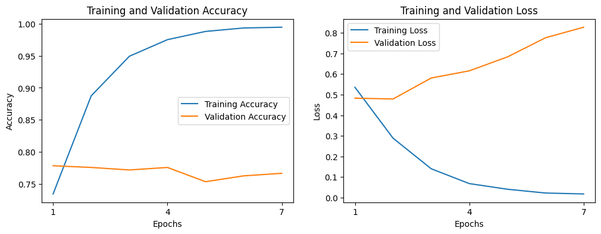

```python
plot_results(model_lstm_results)
```

```python
model_lstm = Sequential()

model_lstm.add(Input(
    shape = (texts_seq_pad.shape[1],) # length of the input vectors (i.e. encoded texts)
))

model_lstm.add(Embedding(
    input_dim = len(tz.word_index) + 1 # size of the vocabulary.
    ,output_dim = 10 # length of the dense output vectors (i.e. embeddings).
))

model_lstm.add(LSTM(
    units = 16 # dimensionality of the output space, should be set to a power of 2.
))

model_lstm.add(Dense(
    units = 1
    ,activation = 'sigmoid' # to output a probability
))

model_lstm.compile(loss = 'binary_crossentropy', optimizer = 'adam', metrics = ['accuracy'])

model_lstm.summary()
```

```
Model: "sequential_1"
```

```
┏━━━━━━━━━━━━━━━━━━━━━━━━━━━━━━━━━━━━━━┳━━━━━━━━━━━━━━━━━━━━━━━━━━━━━┳━━━━━━━━━━━━━━━━━┓
┃ Layer (type)                         ┃ Output Shape                ┃         Param # ┃
┡━━━━━━━━━━━━━━━━━━━━━━━━━━━━━━━━━━━━━━╇━━━━━━━━━━━━━━━━━━━━━━━━━━━━━╇━━━━━━━━━━━━━━━━━┩
│ embedding_1 (Embedding)              │ (None, 31, 10)              │         226,980 │
├──────────────────────────────────────┼─────────────────────────────┼─────────────────┤
│ lstm_1 (LSTM)                        │ (None, 16)                  │           1,728 │
├──────────────────────────────────────┼─────────────────────────────┼─────────────────┤
│ dense_1 (Dense)                      │ (None, 1)                   │              17 │
└──────────────────────────────────────┴─────────────────────────────┴─────────────────┘
```

```
 Total params: 228,725 (893.46 KB)
```

```
 Trainable params: 228,725 (893.46 KB)
```

```
 Non-trainable params: 0 (0.00 B)
```

```
215/215 ━━━━━━━━━━━━━━━━━━━━ 4s 7ms/step - accuracy: 0.6013 - loss: 0.6608 - val_accuracy: 0.7677 - val_loss: 0.5128 - learning_rate: 0.0010
215/215 ━━━━━━━━━━━━━━━━━━━━ 1s 5ms/step - accuracy: 0.8377 - loss: 0.3988 - val_accuracy: 0.7927 - val_loss: 0.4601 - learning_rate: 0.0010
215/215 ━━━━━━━━━━━━━━━━━━━━ 1s 5ms/step - accuracy: 0.9130 - loss: 0.2389 - val_accuracy: 0.7795 - val_loss: 0.4827 - learning_rate: 0.0010
215/215 ━━━━━━━━━━━━━━━━━━━━ 1s 6ms/step - accuracy: 0.9454 - loss: 0.1627 - val_accuracy: 0.7874 - val_loss: 0.5384 - learning_rate: 0.0010
209/215 ━━━━━━━━━━━━━━━━━━━━ 0s 5ms/step - accuracy: 0.9701 - loss: 0.0960
Epoch 5: ReduceLROnPlateau reducing learning rate to 0.00010000000474974513.
215/215 ━━━━━━━━━━━━━━━━━━━━ 1s 5ms/step - accuracy: 0.9700 - loss: 0.0962 - val_accuracy: 0.7887 - val_loss: 0.5657 - learning_rate: 0.0010
215/215 ━━━━━━━━━━━━━━━━━━━━ 1s 6ms/step - accuracy: 0.9816 - loss: 0.0634 - val_accuracy: 0.7822 - val_loss: 0.6228 - learning_rate: 1.0000e-04
215/215 ━━━━━━━━━━━━━━━━━━━━ 1s 6ms/step - accuracy: 0.9854 - loss: 0.0522 - val_accuracy: 0.7598 - val_loss: 0.6646 - learning_rate: 1.0000e-04
Epoch 7: early stopping
Restoring model weights from the end of the best epoch: 2.
```

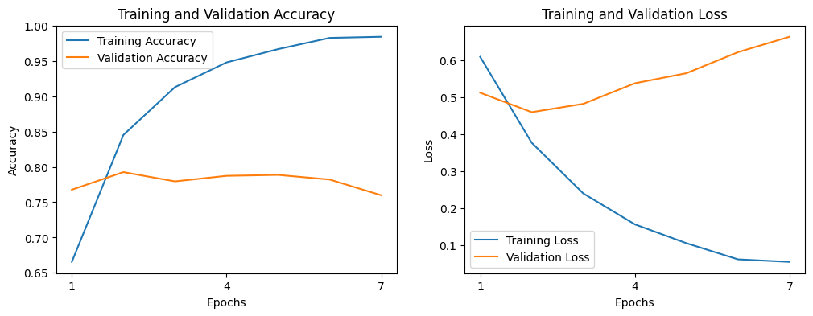

```python
model_lstm_results = model_lstm.fit(x = texts_seq_pad, y = train['target'], epochs = 40, validation_split = 0.1, callbacks = [es, rl])
plot_results(model_lstm_results)
```

There's not much difference in the model performance besides a small drop in the max validation loss during training. The training process was materially faster since there are much less learnable parameters.

### Using pre-trained embeddings (GloVe)

Instead of training the embedding layer from scratch, let's try using pre-trained embeddings instead. The goal of the embedding layer is to learn the semantic relationships between words to derive meaning. With only the ~8K samples in our dataset, the model may be learning a relationship that exists in the training dataset which isn't valid for any data outside of it. The benefit of pre-trained embeddings is that they're trained on a much larger corpus of texts, and so have a much better understanding of the true relationship between words that exists in the majority of text datasets.

```python
# read in GloVe embeddings txt file, and save embeddings in a dict
embeddings_dict = {}

f = open('/kaggle/input/glove-6b-100/glove.6B.100d.txt', 'r')
for line in f:
    line_split = line.split()
    word = line_split[0]
    embedding = line_split[1:]
    embeddings_dict[word] = embedding
f.close()
```

```python
# example what an embedding looks like
w = list(embeddings_dict)[15]
print(f"{w}: {embeddings_dict[w]}")
print(f"Length:{len(embeddings_dict[w])}")
```

```
was: ['0.13717', '-0.54287', '0.19419', '-0.29953', '0.17545', '0.084672', '0.67752', '0.098295', '-0.035611', '0.21334', '0.51663', '0.20687', '0.44082', '-0.33655', '0.56025', '-0.6879', '0.51957', '-0.21258', '-0.52708', '-0.12249', '0.33099', '0.026448', '0.59007', '0.0065469', '0.45405', '-0.33…
Length:100
```

```python
# create matrix of GloVe embeddings for the words in our training data
embeddings_matrix = np.zeros((len(tz.word_index) + 1, 100))

for i, word in enumerate(list(tz.word_index)):
    embed = embeddings_dict.get(word)

    if embed is not None:
        embeddings_matrix[i] = embed
    # for words with no pre-trained embedding, their embedding will be all zeros and effectively ignored by the model
```

### RNN with LSTM Layer - using GloVe embeddings

Let's build the same model as before, but modify the Embedding layer to use the pre-trained GloVe embeddings as weights, instead of trying to learn them.

```python
model_lstm_glove = Sequential()

model_lstm_glove.add(Input(
    shape = (texts_seq_pad.shape[1],) # length of the input vectors (i.e. encoded texts)
))

model_lstm_glove.add(Embedding(
    input_dim = len(tz.word_index) + 1 # size of the vocabulary.
    ,output_dim = 100 # length of the dense output vectors (i.e. embeddings).
    ,embeddings_initializer = Constant(embeddings_matrix) # use pre-trained embeddings from GloVe
    ,trainable = False # don't train, only use the pre-trained weights defined in the GloVe embeddings
))

model_lstm_glove.add(LSTM(
    units = 16 # dimensionality of the output space, should be set to a power of 2. seen 32 and 64 used in other notebooks.
))

model_lstm_glove.add(Dense(
    units = 1
    ,activation = 'sigmoid' # to output a probability
))

model_lstm_glove.compile(loss = 'binary_crossentropy', optimizer = 'adam', metrics = ['accuracy'])

model_lstm_glove.summary()
```

```
Model: "sequential_2"
```

```
┏━━━━━━━━━━━━━━━━━━━━━━━━━━━━━━━━━━━━━━┳━━━━━━━━━━━━━━━━━━━━━━━━━━━━━┳━━━━━━━━━━━━━━━━━┓
┃ Layer (type)                         ┃ Output Shape                ┃         Param # ┃
┡━━━━━━━━━━━━━━━━━━━━━━━━━━━━━━━━━━━━━━╇━━━━━━━━━━━━━━━━━━━━━━━━━━━━━╇━━━━━━━━━━━━━━━━━┩
│ embedding_2 (Embedding)              │ (None, 31, 100)             │       2,269,800 │
├──────────────────────────────────────┼─────────────────────────────┼─────────────────┤
│ lstm_2 (LSTM)                        │ (None, 16)                  │           7,488 │
├──────────────────────────────────────┼─────────────────────────────┼─────────────────┤
│ dense_2 (Dense)                      │ (None, 1)                   │              17 │
└──────────────────────────────────────┴─────────────────────────────┴─────────────────┘
```

```
 Total params: 2,277,305 (8.69 MB)
```

```
 Trainable params: 7,505 (29.32 KB)
```

```
 Non-trainable params: 2,269,800 (8.66 MB)
```

```
215/215 ━━━━━━━━━━━━━━━━━━━━ 3s 7ms/step - accuracy: 0.5982 - loss: 0.6613 - val_accuracy: 0.6089 - val_loss: 0.6547 - learning_rate: 0.0010
215/215 ━━━━━━━━━━━━━━━━━━━━ 1s 5ms/step - accuracy: 0.6724 - loss: 0.6176 - val_accuracy: 0.6667 - val_loss: 0.6210 - learning_rate: 0.0010
215/215 ━━━━━━━━━━━━━━━━━━━━ 1s 5ms/step - accuracy: 0.6932 - loss: 0.5849 - val_accuracy: 0.6995 - val_loss: 0.5723 - learning_rate: 0.0010
215/215 ━━━━━━━━━━━━━━━━━━━━ 1s 5ms/step - accuracy: 0.7151 - loss: 0.5583 - val_accuracy: 0.7297 - val_loss: 0.5583 - learning_rate: 0.0010
215/215 ━━━━━━━━━━━━━━━━━━━━ 1s 5ms/step - accuracy: 0.7253 - loss: 0.5423 - val_accuracy: 0.7454 - val_loss: 0.5520 - learning_rate: 0.0010
215/215 ━━━━━━━━━━━━━━━━━━━━ 1s 5ms/step - accuracy: 0.7470 - loss: 0.5187 - val_accuracy: 0.7178 - val_loss: 0.5481 - learning_rate: 0.0010
215/215 ━━━━━━━━━━━━━━━━━━━━ 1s 5ms/step - accuracy: 0.7565 - loss: 0.4985 - val_accuracy: 0.7297 - val_loss: 0.5512 - learning_rate: 0.0010
215/215 ━━━━━━━━━━━━━━━━━━━━ 1s 5ms/step - accuracy: 0.7778 - loss: 0.4718 - val_accuracy: 0.7152 - val_loss: 0.5733 - learning_rate: 0.0010
205/215 ━━━━━━━━━━━━━━━━━━━━ 0s 5ms/step - accuracy: 0.7903 - loss: 0.4560
Epoch 9: ReduceLROnPlateau reducing learning rate to 0.00010000000474974513.
215/215 ━━━━━━━━━━━━━━━━━━━━ 1s 5ms/step - accuracy: 0.7901 - loss: 0.4562 - val_accuracy: 0.7139 - val_loss: 0.5693 - learning_rate: 0.0010
215/215 ━━━━━━━━━━━━━━━━━━━━ 1s 5ms/step - accuracy: 0.8091 - loss: 0.4339 - val_accuracy: 0.7336 - val_loss: 0.5604 - learning_rate: 1.0000e-04
215/215 ━━━━━━━━━━━━━━━━━━━━ 1s 5ms/step - accuracy: 0.8107 - loss: 0.4279 - val_accuracy: 0.7310 - val_loss: 0.5626 - learning_rate: 1.0000e-04
Epoch 11: early stopping
Restoring model weights from the end of the best epoch: 6.
```

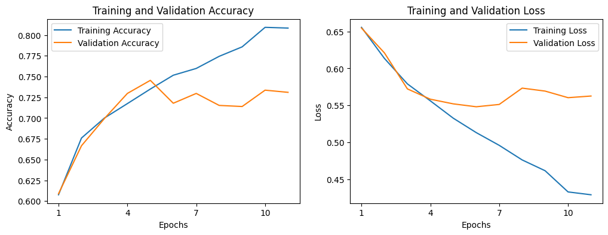

```python
model_lstm_glove_results = model_lstm_glove.fit(x = texts_seq_pad, y = train['target'], epochs = 40, validation_split = 0.1, callbacks = [es, rl])
plot_results(model_lstm_glove_results)
```

In this model, validation loss doesn't have as much of an increasing trend which is a sign of less overfitting. However, the accuracy for both training and validation is considerably lower than for the base model. The primary change we made is using pre-trained embeddings, so clearly using the learned embeddings from our training data resulted in better performance overall.

### RNN with LSTM Layer - using Dropout layer

Let's step back and remember that we had the highest validation accuracy so far with our initial model, before using the pre-trained GloVe embeddings. However, overfitting was a big issue, so let's try utilizing the dropout layer with the base model but no pre-trained glove embeddings, i.e., go back to using our own trained embeddings.

```python
model_lstm_dropout = Sequential()

model_lstm_dropout.add(Input(
    shape = (texts_seq_pad.shape[1],) # length of the input vectors (i.e. encoded texts)
))

model_lstm_dropout.add(Embedding(
    input_dim = len(tz.word_index) + 1 # size of the vocabulary.
    ,output_dim = 10 # length of the dense output vectors (i.e. embeddings).
))

model_lstm_dropout.add(LSTM(
    units = 16 # dimensionality of the output space, should be set to a power of 2. seen 32 and 64 used in other notebooks.
))

model_lstm_dropout.add(Dropout(
    rate = 0.5 # 50% of weights are randomly set to zero
))

model_lstm_dropout.add(Dense(
    units = 1
    ,activation = 'sigmoid' # to output a probability
))

model_lstm_dropout.compile(loss = 'binary_crossentropy', optimizer = 'adam', metrics = ['accuracy'])

model_lstm_dropout.summary()
```

```
Model: "sequential_3"
```

```
┏━━━━━━━━━━━━━━━━━━━━━━━━━━━━━━━━━━━━━━┳━━━━━━━━━━━━━━━━━━━━━━━━━━━━━┳━━━━━━━━━━━━━━━━━┓
┃ Layer (type)                         ┃ Output Shape                ┃         Param # ┃
┡━━━━━━━━━━━━━━━━━━━━━━━━━━━━━━━━━━━━━━╇━━━━━━━━━━━━━━━━━━━━━━━━━━━━━╇━━━━━━━━━━━━━━━━━┩
│ embedding_3 (Embedding)              │ (None, 31, 10)              │         226,980 │
├──────────────────────────────────────┼─────────────────────────────┼─────────────────┤
│ lstm_3 (LSTM)                        │ (None, 16)                  │           1,728 │
├──────────────────────────────────────┼─────────────────────────────┼─────────────────┤
│ dropout (Dropout)                    │ (None, 16)                  │               0 │
├──────────────────────────────────────┼─────────────────────────────┼─────────────────┤
│ dense_3 (Dense)                      │ (None, 1)                   │              17 │
└──────────────────────────────────────┴─────────────────────────────┴─────────────────┘
```

```
 Total params: 228,725 (893.46 KB)
```

```
 Trainable params: 228,725 (893.46 KB)
```

```
 Non-trainable params: 0 (0.00 B)
```

```python
model_lstm_dropout_results = model_lstm_dropout.fit(x = texts_seq_pad, y = train['target'], epochs = 40, validation_split = 0.1, callbacks = [es, rl])
```

```
215/215 ━━━━━━━━━━━━━━━━━━━━ 5s 8ms/step - accuracy: 0.5660 - loss: 0.6746 - val_accuracy: 0.7362 - val_loss: 0.5594 - learning_rate: 0.0010
215/215 ━━━━━━━━━━━━━━━━━━━━ 1s 6ms/step - accuracy: 0.8286 - loss: 0.4524 - val_accuracy: 0.7979 - val_loss: 0.4456 - learning_rate: 0.0010
215/215 ━━━━━━━━━━━━━━━━━━━━ 1s 6ms/step - accuracy: 0.9066 - loss: 0.2687 - val_accuracy: 0.7861 - val_loss: 0.4630 - learning_rate: 0.0010
215/215 ━━━━━━━━━━━━━━━━━━━━ 1s 6ms/step - accuracy: 0.9453 - loss: 0.1868 - val_accuracy: 0.7795 - val_loss: 0.5792 - learning_rate: 0.0010
211/215 ━━━━━━━━━━━━━━━━━━━━ 0s 5ms/step - accuracy: 0.9631 - loss: 0.1217
Epoch 5: ReduceLROnPlateau reducing learning rate to 0.00010000000474974513.
215/215 ━━━━━━━━━━━━━━━━━━━━ 1s 6ms/step - accuracy: 0.9631 - loss: 0.1217 - val_accuracy: 0.7756 - val_loss: 0.6032 - learning_rate: 0.0010
215/215 ━━━━━━━━━━━━━━━━━━━━ 1s 6ms/step - accuracy: 0.9789 - loss: 0.0776 - val_accuracy: 0.7756 - val_loss: 0.6266 - learning_rate: 1.0000e-04
215/215 ━━━━━━━━━━━━━━━━━━━━ 1s 6ms/step - accuracy: 0.9833 - loss: 0.0643 - val_accuracy: 0.7769 - val_loss: 0.6505 - learning_rate: 1.0000e-04
Epoch 7: early stopping
Restoring model weights from the end of the best epoch: 2.
```

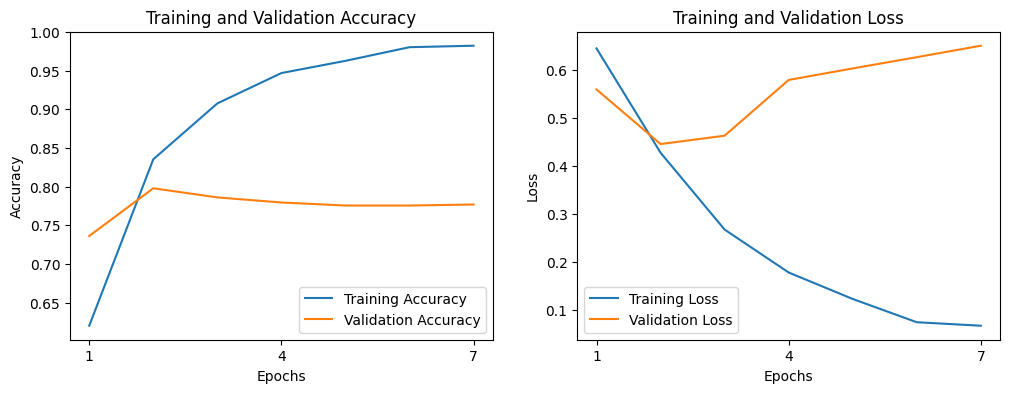

```python
plot_results(model_lstm_dropout_results)
```

### RNN with GRU Layer

Let's pivot to using a GRU layer, which is a simplified version of the LSTM layer, to see if it performs better in training.

```python
model_gru = Sequential()

model_gru.add(Input(
    shape = (texts_seq_pad.shape[1],) # length of the input vectors (i.e. encoded texts)
))

model_gru.add(Embedding(
    input_dim = len(tz.word_index) + 1 # size of the vocabulary.
    ,output_dim = 10 # length of the dense output vectors (i.e. embeddings).
))

model_gru.add(GRU(
    units = 16 # dimensionality of the output space, should be set to a power of 2. seen 32 and 64 used in other notebooks.
))

model_gru.add(Dense(
    units = 1
    ,activation = 'sigmoid' # to output a probability
))

model_gru.compile(loss = 'binary_crossentropy', optimizer = 'adam', metrics = ['accuracy'])

model_gru.summary()
```

```
Model: "sequential_4"
```

```
┏━━━━━━━━━━━━━━━━━━━━━━━━━━━━━━━━━━━━━━┳━━━━━━━━━━━━━━━━━━━━━━━━━━━━━┳━━━━━━━━━━━━━━━━━┓
┃ Layer (type)                         ┃ Output Shape                ┃         Param # ┃
┡━━━━━━━━━━━━━━━━━━━━━━━━━━━━━━━━━━━━━━╇━━━━━━━━━━━━━━━━━━━━━━━━━━━━━╇━━━━━━━━━━━━━━━━━┩
│ embedding_4 (Embedding)              │ (None, 31, 10)              │         226,980 │
├──────────────────────────────────────┼─────────────────────────────┼─────────────────┤
│ gru (GRU)                            │ (None, 16)                  │           1,344 │
├──────────────────────────────────────┼─────────────────────────────┼─────────────────┤
│ dense_4 (Dense)                      │ (None, 1)                   │              17 │
└──────────────────────────────────────┴─────────────────────────────┴─────────────────┘
```

```
 Total params: 228,341 (891.96 KB)
```

```
 Trainable params: 228,341 (891.96 KB)
```

```
 Non-trainable params: 0 (0.00 B)
```

```
215/215 ━━━━━━━━━━━━━━━━━━━━ 3s 7ms/step - accuracy: 0.5920 - loss: 0.6655 - val_accuracy: 0.7021 - val_loss: 0.5426 - learning_rate: 0.0010
215/215 ━━━━━━━━━━━━━━━━━━━━ 1s 6ms/step - accuracy: 0.8282 - loss: 0.3941 - val_accuracy: 0.7927 - val_loss: 0.4490 - learning_rate: 0.0010
215/215 ━━━━━━━━━━━━━━━━━━━━ 1s 6ms/step - accuracy: 0.9287 - loss: 0.1944 - val_accuracy: 0.7677 - val_loss: 0.5059 - learning_rate: 0.0010
215/215 ━━━━━━━━━━━━━━━━━━━━ 1s 5ms/step - accuracy: 0.9627 - loss: 0.1111 - val_accuracy: 0.7717 - val_loss: 0.5753 - learning_rate: 0.0010
209/215 ━━━━━━━━━━━━━━━━━━━━ 0s 5ms/step - accuracy: 0.9825 - loss: 0.0586
Epoch 5: ReduceLROnPlateau reducing learning rate to 0.00010000000474974513.
215/215 ━━━━━━━━━━━━━━━━━━━━ 1s 5ms/step - accuracy: 0.9824 - loss: 0.0587 - val_accuracy: 0.7480 - val_loss: 0.6784 - learning_rate: 0.0010
215/215 ━━━━━━━━━━━━━━━━━━━━ 1s 5ms/step - accuracy: 0.9914 - loss: 0.0322 - val_accuracy: 0.7520 - val_loss: 0.6947 - learning_rate: 1.0000e-04
215/215 ━━━━━━━━━━━━━━━━━━━━ 1s 5ms/step - accuracy: 0.9918 - loss: 0.0296 - val_accuracy: 0.7612 - val_loss: 0.6911 - learning_rate: 1.0000e-04
Epoch 7: early stopping
Restoring model weights from the end of the best epoch: 2.
```

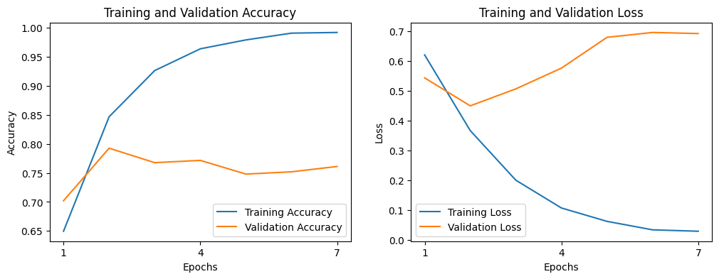

```python
model_gru_results = model_gru.fit(x = texts_seq_pad, y = train['target'], epochs = 40, validation_split = 0.1, callbacks = [es, rl])
plot_results(model_gru_results)
```

The top validation accuracy is 80%, and the validation loss is not much better than the previous models we've tried.